# Functions and packages

## Installing packages

In today’s practical we’ll learn how to extend the functionality of `R` by using **packages** and we’ll learn how to use **functions** in `R`.

### Installing packages from CRAN

We’ll start off with a refresher on installing packages by installing a package called `here`. The `here` package will give you access to a function called `here()`. Like most of the packages that we’ll be working with, this package is on the CRAN.

To install packages on the CRAN we’ll use a **function** called `install.packages()`. The `install.packages()` function only takes one input. This input is a *string of letters* giving the **package name**.

To install the **here** package you’d run the following command:

```r
install.packages("here")
```

**Where do you run this command?**  
When you want to run commands to *install `R` packages* you run them in the **Console** pane. Run the command above by typing it into the **Console**.

If a dialogue box like the one below pops up then just click **No**

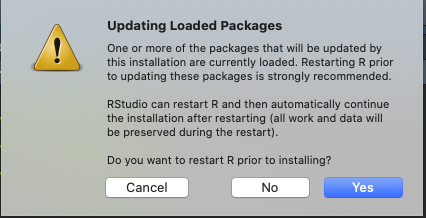

If you’re able to install the package successfully then you should see something like the output below.

```markdown
> install.packages("here")
trying URL 'https://cran.rstudio.com/bin/macosx/contrib/4.0/here_0.1.tgz'
Content type 'application/x-gzip' length 18008 bytes (17 KB)
==================================================
downloaded 17 KB


The downloaded binary packages are in
    /var/folders/71/svr64pcx1mn0rq9141lk4dgw001d5z/T//Rtmp03fU6r/downloaded_packages
```

When installing new packages the easiest way to check whether the package has been *installed correctly* is to try *loading* it.

For example, if you’ve just tried to install a package called `nonpackage`, then you can check whether it is installed correctly by loading it with the `library()` function. If you don’t get an error message then everything is OK! However, if you get an error message like the one below, then that means the package hasn’t been installed correctly.

```markdown
> library(nonpackage)
Error in library("nonpackage") : there is no package called ‘nonpackage’
```

You can also spot installation errors by looking at the messages at the end of the installation process.

For example, if a package doesn’t install because you’ve typed the package name in incorrectly then you’ll see a message telling you the package **is not available**:

```markdown
> install.packages("doesnotexist")
Warning message:
package ‘doesnotexist’ is not available (for R version 4.0.2)
```

If you’ve typed the name in correctly by the installation has failed for some other reasons then you’ll see a message telling you that the installation **had a non-zero exit status**:

```markdown
The downloaded source packages are in
‘/private/var/folders/71/svr64pcx1mn0rq9141lk4dgw001d5z/T/RtmpLO2yBg/downloaded_packages’
Warning message:
In install.packages("rJava") :
installation of package ‘rJava’ had non-zero exit status
```

### Installing not on the CRAN

A minority of packages that we’ll be using are not on the CRAN. To install these packages we’ll use a function from the **remotes** package called `remotes::install_url()` or `remotes::install_github()`.

The `remotes::install_url()` function just takes one input. This is a letter string that is a URL (that is, a web address starting with `http://` or `https://`).

The `remotes::install_github()` function also takes one input. This is a litter string that will be the location of a **GitHub** repository. It’s input will look something like this: `SussexPsychMethods/paas`. Notice that it doesn’t have any `http://` or `https://` at the start. You’ll almost always be told by the package developer whether you should use **install_url** or **install_github**.

### Updating packages

Sometimes the people that make `R` packages will *update* them. This might be because they want to correct errors in them or because they’ve added some new functionality. **Updating** packages is just as easy as **installing** them. To update a package all you need to do is run the install command again.

For example, if you used the following command to install a package:

```r
install.packages("here")
```

You’d use the exact same command to update it.

And if you used the following command to install a package:

```r
remotes::install_url(url = "https://paas.netlify.app/packages/paas.zip")
```

You’d also use the exact same command to update it.

## Using packages and functions

Once you’ve installed a package you can start using the functions that it brings with it. To do this, you should first load the package using the `library()` function. The `library()` function just takes one input. This is a letter string with the name of the package.

For example, the command below would load the **here** package.

```r
library("here")
```

When you want to use a function from a package, you should put the **package name** before the **function name**. For example, if I wanted to use the `install_url()` function from the **remotes** package I would write:

```r
remotes::install_url(url = ...)
```

## Getting help on functions

The easiest way to get help on a function is to use the `?`. To get help, you just put a `?` before the function call. Remember, don’t forget the `()`!

To get help on the `here()` function from the **here** package, you’d write the following at the **console**

```r
?here::here()
```

## Tasks

Now that you’ve had a bit of a refresher on functions and packages we’ll put that knowledge to use to solve the following tasks.

### Task 1

First up, create a **new** **RMarkdown** (`.Rmd`) file and save it in the `rdocs` folder of your current project folder. You’ll be writing your solutions into this file. You can give it whatever name you want.

### Task 2

Next, clear out the `.Rmd` file by deleting everything below the first code chunk (the **setup** chunk).

### Task 3

We’ll be using three packages for today’s tasks. Two packages will be installed from **CRAN** and the third will be a **non-CRAN** package.

1. First install the **here** package and the **knitr** package from **CRAN**.
2. Next install the **non-CRAN** package called **learnfun** from the **URL** `https://paas.netlify.app/packages/learnfun.zip`

Make sure to install these packages by running the commands in the correct way.

The commands should be run at the **console**.

```r
install.packages("here")
install.packages("knitr")
remotes::install_url(url = "https://paas.netlify.app/packages/learnfun.zip")
```

```r
install.packages("here")
install.packages("knitr")
remotes::install_url(url = "https://paas.netlify.app/packages/learnfun.zip")
```

### Task 4

We’ll be using the **here**, the **knitr**, and the **learnfun** packages, so add some code to the **setup** chunk of your `.Rmd` file so that these packages will be loaded whenever you **knit** the document.

use the `library()` function to load a package.

Put this code in the very first code chunk (the **setup** chunk).

```r
library("knitr")
library("here")
library("learnfun")
```

### Task 5

Now create a new **code chunk** in your `.Rmd` file.

Copy the code below and paste it into the **code chunk**

```r
rnorm(n = 100, mean = 0, sd = 1)
```

This function simply generates 100 random numbers from the **normal distribution** with a mean ($\mu$) of 0 and a standard deviation ($\sigma$) of 1.

Edit the line of code so that the output is assigned to a variable called `my_random_numbers`.

You just need to add the object name (`my_random_numbers`) and the assignment arrow (`<-`) to the start of the line before the `rnorm()` function is called.

```r
my_random_numbers <- rnorm(n = 100, mean = 0, sd = 1)
```

### Task 6

Next we’ll use the object we created in the previous step (`my_random_numbers`) as the input to the `mean()` function.

If you’re unsure of how to use a function then you can ask `R` for **help**. To do this, you just use a `?` before the function name and then call the function without any inputs. Because this is just a one-off command you’d type it at the console. (Putting it in the `.Rmd` would mean asking for help every time you **knit** your file!)

For example, if you wanted help about the `mean()` function, then you’d type the following into the console

```r
?mean()
```

Now try accessing the help on the **mean** function, and see where it appears in your **help** pane.

### Task 7

Use the `mean()` function to work out the mean of the vector of numbers you just created. Add this code to the code chunk.

```r
mean(x = my_random_numbers)
```

### Task 8

Now that you know how to get help, try accessing the help for the **rankitems** function from the **learnfun** package.

```r
?learnfun::rankitems()
```

### Task 9

After you’ve read the help on the **rankitems** function, add a new code chunk to your `.Rmd` file and use the **rankitems** function to do something sensible with it.

```r
learnfun::rankitems(fav = "Pizza",
  second = "Sushi",
  hated = "Coriander")
```

### Task 10

Next we will try and include an image into our `.Rmd` file. We will do this in a few steps.

First, we’ll need an image. To download the image click HERE.

Either save the image directly into the `images` sub-folder of you project or move it from your downloads folder to the `images` sub-folder of your project.

If you’re having trouble downloading the file and then uploading to `RStudio` cloud then you can try using the `download.file()` function. First create your `images` folder, and then run the following command: `download.file(url = "https://paas.netlify.app/assets/rollercoaster.png", destfile = "/images/rollercoaster.png")`

For people using chromebooks/the cloud version of `R` it might be easier for them to use the `download.file()` function.

```r
download.file(url = "https://paas.netlify.app/assets/rollercoaster.png", destfile = "/images/rollercoaster.png")
```

### Task 11

Create a new code chunk. In this code chunk use the `here::here()` function to give the directions to the image file that you’ve just downloaded. Make sure you assign the directions to an object called `imagefile`

You’ll write the directions to the file in the same way you did in [Week 3](https://paas.netlify.app/archive/2020/practicals/02_project_files/worksheets), in the section *Finding the path to a file*.

```r
imagefile <- here::here("images/rollercoaster.png")
```

### Task 12

In the same code chunk as before, use the `knitr::include_graphics()` function to include the image in your document. Use the `imagefile` object as the input for the **include_graphics** function.

```r
imagefile <- here::here("images/rollercoaster.png")
knitr::include_graphics(path = imagefile)
```

### Task 13

An important skill to learn is how to diagnose **problems** with your code. Create a new code chunk in your `.Rmd` file and insert the code below into the code chunk.

```r
a_number <- 10
learnfun::number_and_word(number = a_number, word = a_word)
```

Now try running the **code chunk**. You’ll notice that it produces an error. Make some changes to the **code chunk** so that it produces the following output.

```markdown
The number is  10  and the word is  cat
```

Don’t edit the line that starts with `learnfun::`

```r
a_number <- 10
a_word <- "cat"
learnfun::number_and_word(number = a_number, word = a_word)
```

### Task 14

I hope the last one was easy, so we’ll make it a little more complicated now.

Create a new **code chunk** and copy the code below into the code chunk. Take a look at the comments in the code to give you an idea of what different bits of the code are doing.

```r
# Create an object with an animal name
animal <- "Elephant"

# Create an object with a location
lives_in <- "Africa"

# Create an object with an age
age <- "70"

# get information about an animal
learnfun::animal_info(name = animl, where = lives_in, lifespan = age)
```

This code will produce an error (or two), so you’ll have to fix it so that it works correctly. When it works correctly it should print out the following message

```markdown
Elephant  live in  Africa and live for  70  years

# A tibble: 1 x 4
  name     where  lifespan_years lifespan_months
  <chr>    <chr>           <dbl>           <dbl>
1 Elephant Africa             70             770
```

```r
# Create an object with an animal name
animal <- "Elephant"

# Create an object with a location
lives_in <- "Africa"

# Create an object with an age
age <- 70 # should be a number

# get information about an animal
learnfun::animal_info(name = animal,  # spelling error
                      where = lives_in,
                      lifespan = age)
```

### Task 15

The `learnfun::animal_info()` function prints out a message, but it also outputs a new object (a tibble). But only if you assign the output to an object.

Edit the code chunk so that the output of the `learnfun::animal_info()` function is assigned to an object called `elephant_info`.

```r
elephant_info <- learnfun::animal_info(name = animal, where = lives_in, lifespan = age)
```

### Task 16

Now take a look at the `elephant_info` object. You’ll notice that it has two columns that have numbers in them. One is called `lifespan_years` and the other is called `lifespan_months`.

Do you notice anything weird?

Write some code to check whether the value in `lifespan_months` is 12 times the values in `lifespan_years`. Essentially, just check whether the conversion from life span in years to life span in months has been done correctly!

You’ll need to use the logical operators (one of `==`, `!=`, `>`, `<`, `>=`, `<=`, etc)

Remember to use the `$` to select a column of a tibble.

To check whether one object/value is equal to another you’d use `==`.

```r
elephant_info$lifespan_years * 12 == elephant_info$lifespan_months

# or

elephant_info$lifespan_months / 12 == elephant_info$lifespan_years
```